# R Data Import and Export

Feng Li

School of Statistics and Mathematics

Central University of Finance and Economics

feng.li@cufe.edu.cn

https://feng.li/statcomp

*>>> Link to Python version* [1](https://feng.li/files/python/P04-Python-for-Finance-Tasks/L04.1-Reading-and-Cleaning-Excel-Files.slides.html)

## Plain Text Format

- Read a file in table format (`.csv`, `.txt`, `.dat`) and creates a data frame from it.
  - `read.table()`
  - `read.csv()`
  - `read.csv2()`
- Write a file in text format.
  - `write.table()`
  - `write.csv()`
  - `write.csv2()`

```r
mytable <- read.table(file = "data/table1.txt", sep = "\t", header = TRUE)
mytable
```

A data.frame: 50 × 5

| STATE <chr> | Y1 <dbl> | Y2 <dbl> | X1 <dbl> | X2 <dbl> |
| --- | --- | --- | --- | --- |
| AL | 2206.0 | 2186.0 | 92.7 | 91.4 |
| AK | 0.7 | 0.7 | 151.0 | 149.0 |
| AZ | 73.0 | 74.0 | 61.0 | 56.0 |
| AR | 3620.0 | 3737.0 | 86.3 | 91.8 |
| CA | 7472.0 | 7444.0 | 63.4 | 58.4 |
| CO | 788.0 | 873.0 | 77.8 | 73.0 |
| CT | 1029.0 | 948.0 | 106.0 | 104.0 |
| DE | 168.0 | 164.0 | 117.0 | 113.0 |
| FL | 2568.0 | 2537.0 | 62.0 | 57.2 |
| GA | 4302.0 | 4301.0 | 80.6 | 80.8 |
| HI | 227.5 | 224.5 | 85.0 | 85.5 |
| ID | 187.0 | 203.0 | 79.1 | 72.9 |
| IL | 793.0 | 809.0 | 65.0 | 70.5 |
| IN | 5445.0 | 5290.0 | 62.7 | 60.1 |
| IA | 2151.0 | 2247.0 | 56.5 | 53.0 |
| KS | 404.0 | 389.0 | 54.5 | 47.8 |
| KY | 412.0 | 483.0 | 67.7 | 73.5 |
| LA | 273.0 | 254.0 | 115.0 | 115.0 |
| ME | 1069.0 | 1070.0 | 101.0 | 97.0 |
| MD | 885.0 | 898.0 | 76.6 | 75.4 |
| MA | 235.0 | 237.0 | 105.0 | 102.0 |
| MI | 1406.0 | 1396.0 | 58.0 | 53.8 |
| MN | 2499.0 | 2697.0 | 57.7 | 54.0 |
| MS | 1434.0 | 1468.0 | 87.8 | 86.7 |
| MO | 1580.0 | 1622.0 | 55.4 | 51.5 |
| MT | 172.0 | 164.0 | 68.0 | 66.0 |
| NE | 1202.0 | 1400.0 | 50.3 | 48.9 |
| NV | 2.2 | 1.8 | 53.9 | 52.7 |
| NH | 43.0 | 49.0 | 109.0 | 104.0 |
| NJ | 442.0 | 491.0 | 85.0 | 83.0 |
| NM | 283.0 | 302.0 | 74.0 | 70.0 |
| NY | 975.0 | 987.0 | 68.1 | 64.0 |
| NC | 3033.0 | 3045.0 | 82.8 | 78.7 |
| ND | 51.0 | 45.0 | 55.2 | 48.0 |
| OH | 4667.0 | 4637.0 | 59.1 | 54.7 |
| OK | 869.0 | 830.0 | 101.0 | 100.0 |
| OR | 652.0 | 686.0 | 77.0 | 74.6 |
| PA | 4976.0 | 5130.0 | 61.0 | 52.0 |
| RI | 53.0 | 50.0 | 102.0 | 99.0 |
| SC | 1422.0 | 1420.0 | 70.1 | 65.9 |
| SD | 435.0 | 602.0 | 48.0 | 45.8 |
| TN | 277.0 | 279.0 | 71.0 | 80.7 |
| TX | 3317.0 | 3356.0 | 76.7 | 72.6 |
| UT | 456.0 | 486.0 | 64.0 | 59.0 |
| VT | 31.0 | 30.0 | 106.0 | 102.0 |
| VA | 934.0 | 988.0 | 86.3 | 81.2 |
| WA | 1287.0 | 1313.0 | 74.1 | 71.5 |
| WV | 136.0 | 174.0 | 104.0 | 109.0 |
| WI | 910.0 | 873.0 | 60.1 | 54.0 |
| WY | 1.7 | 1.7 | 83.0 | 83.0 |

```r
as.matrix(mytable[, 2:5]) # Convert to a Matrix format
```

A matrix: 50 × 4 of type dbl

| Y1 | Y2 | X1 | X2 |
| --- | --- | --- | --- |
| 2206.0 | 2186.0 | 92.7 | 91.4 |
| 0.7 | 0.7 | 151.0 | 149.0 |
| 73.0 | 74.0 | 61.0 | 56.0 |
| 3620.0 | 3737.0 | 86.3 | 91.8 |
| 7472.0 | 7444.0 | 63.4 | 58.4 |
| 788.0 | 873.0 | 77.8 | 73.0 |
| 1029.0 | 948.0 | 106.0 | 104.0 |
| 168.0 | 164.0 | 117.0 | 113.0 |
| 2568.0 | 2537.0 | 62.0 | 57.2 |
| 4302.0 | 4301.0 | 80.6 | 80.8 |
| 227.5 | 224.5 | 85.0 | 85.5 |
| 187.0 | 203.0 | 79.1 | 72.9 |
| 793.0 | 809.0 | 65.0 | 70.5 |
| 5445.0 | 5290.0 | 62.7 | 60.1 |
| 2151.0 | 2247.0 | 56.5 | 53.0 |
| 404.0 | 389.0 | 54.5 | 47.8 |
| 412.0 | 483.0 | 67.7 | 73.5 |
| 273.0 | 254.0 | 115.0 | 115.0 |
| 1069.0 | 1070.0 | 101.0 | 97.0 |
| 885.0 | 898.0 | 76.6 | 75.4 |
| 235.0 | 237.0 | 105.0 | 102.0 |
| 1406.0 | 1396.0 | 58.0 | 53.8 |
| 2499.0 | 2697.0 | 57.7 | 54.0 |
| 1434.0 | 1468.0 | 87.8 | 86.7 |
| 1580.0 | 1622.0 | 55.4 | 51.5 |
| 172.0 | 164.0 | 68.0 | 66.0 |
| 1202.0 | 1400.0 | 50.3 | 48.9 |
| 2.2 | 1.8 | 53.9 | 52.7 |
| 43.0 | 49.0 | 109.0 | 104.0 |
| 442.0 | 491.0 | 85.0 | 83.0 |
| 283.0 | 302.0 | 74.0 | 70.0 |
| 975.0 | 987.0 | 68.1 | 64.0 |
| 3033.0 | 3045.0 | 82.8 | 78.7 |
| 51.0 | 45.0 | 55.2 | 48.0 |
| 4667.0 | 4637.0 | 59.1 | 54.7 |
| 869.0 | 830.0 | 101.0 | 100.0 |
| 652.0 | 686.0 | 77.0 | 74.6 |
| 4976.0 | 5130.0 | 61.0 | 52.0 |
| 53.0 | 50.0 | 102.0 | 99.0 |
| 1422.0 | 1420.0 | 70.1 | 65.9 |
| 435.0 | 602.0 | 48.0 | 45.8 |
| 277.0 | 279.0 | 71.0 | 80.7 |
| 3317.0 | 3356.0 | 76.7 | 72.6 |
| 456.0 | 486.0 | 64.0 | 59.0 |
| 31.0 | 30.0 | 106.0 | 102.0 |
| 934.0 | 988.0 | 86.3 | 81.2 |
| 1287.0 | 1313.0 | 74.1 | 71.5 |
| 136.0 | 174.0 | 104.0 | 109.0 |
| 910.0 | 873.0 | 60.1 | 54.0 |
| 1.7 | 1.7 | 83.0 | 83.0 |

```r
write.table(mytable, file = "mysavedtable.txt", sep = ",") # save with comma separator
```

## Microsoft Excel

- Install and load the `openxlsx` package.
- Read Excel files with `read.xlsx()` function

  ```
    read.xlsx(xlsxFile, sheet, startRow = 1, colNames = TRUE, rowNames = FALSE, ...)
  ```

- Write Excel files

  ```
  write.xlsx(x, file, asTable = FALSE, overwrite = TRUE, ...)
  ```

```r
# install.packages("openxlsx")
```

```r
require("openxlsx")
mydata <- read.xlsx("data/UNHBDScore.xlsx",
                    sheet = 1,
                    startRow = 1,
                    colNames = TRUE)
mydata
```

A data.frame: 20 × 11

|  | Team <chr> | Slides/Report <chr> | Codes <chr> | Video <chr> | Use.public.data <chr> | Use.big.data <chr> | Theme <dbl> | Innovation <dbl> | Methods <dbl> | Presentation <dbl> | Visualization <dbl> |
| --- | --- | --- | --- | --- | --- | --- | --- | --- | --- | --- | --- |
| 1 | Scipopulis | Yes | Yes | Yes | Yes | Yes | 4 | 3 | 3 | 4 | 4 |
| 2 | Analysts Against Poverty | Yes | Yes | Yes | Yes | No | 3 | 3 | 2 | 3 | 2 |
| 3 | Upside Down | Yes | Yes | No | Yes | Yes | 2 | 2 | 2 | 1 | 2 |
| 4 | safe-encounter.ai | Yes | Yes | Yes | Yes | Yes | 3 | 2 | 1 | 3 | 1 |
| 5 | Big Data and Disasters - ADB | Yes | Yes | Yes | Yes | Yes | 5 | 4 | 5 | 4 | 4 |
| 6 | Datains - Nippon Koei | Yes | Yes | Yes | Yes | Yes | 5 | 3 | 3 | 4 | 4 |
| 7 | Frame | Yes | Yes | Yes | Yes | Yes | 5 | 3 | 2 | 3 | 2 |
| 8 | GC-TICS | Yes | Yes | Yes | Yes | Yes | 3 | 3 | 3 | 4 | 2 |
| 9 | Meaning Maker | Yes | Yes | Yes | Yes | Yes | 4 | 3 | 3 | 4 | 4 |
| 10 | Satria Garuda | Yes | Yes | Yes | Yes | Yes | 3 | 2 | 2 | 2 | 1 |
| 11 | Vegetation Growth | Yes | Yes | Yes | Yes | Yes | 3 | 3 | 3 | 3 | 2 |
| 12 | YOLO (You Only Live Once) | Yes | Yes | Yes | Yes | Yes | 4 | 4 | 3 | 3 | 3 |
| 13 | ZU_ProMinds | Yes | Yes | Yes | Yes | Yes | 3 | 3 | 3 | 3 | 3 |
| 14 | GEMy | Yes | Yes | Yes | Yes | Yes | 4 | 3 | 3 | 3 | 2 |
| 15 | Not wee Data | Yes | Yes | Yes | Yes | Yes | 3 | 3 | 3 | 3 | 2 |
| 16 | MKIT_AIMS2018 | No | Yes | No | Yes | Yes | 2 | 2 | 2 | 1 | 1 |
| 17 | Explorers | Yes | Yes | Yes | Yes | Yes | 4 | 4 | 5 | 5 | 5 |
| 18 | Multiverse of Data | Yes | Yes | Yes | Yes | Yes | 4 | 3 | 4 | 3 | 3 |
| 19 | QUT Centre for Data Science | No | Yes | No | Yes | Yes | 3 | 2 | 2 | 1 | 1 |
| 20 | UAE Diversified Big Data Expert Team | Yes | Yes | Yes | Yes | Yes | 4 | 4 | 3 | 2 | 3 |

## Read and Write MAT Files

- Install and load the `R.matlab` package.
- No Matlab installation required.
- Methods `readMat()` and `writeMat()` for reading and writing MAT files.

```r
# install.packages(R.matlab)
library("R.matlab")
readMat("data/RajanData.mat")
```

```
R.matlab v3.7.0 (2022-08-25 21:52:34 UTC) successfully loaded. See ?R.matlab for help.
```

**$X**

A matrix: 4405 × 5 of type dbl

| 1 | 0.15283128 | 1.0452750 | 6.046561 | 0.08774734 |
| --- | --- | --- | --- | --- |
| 1 | 0.59341052 | 1.6479298 | 3.939774 | 0.18836954 |
| 1 | 0.24067336 | 2.8577454 | 5.757311 | 0.24105133 |
| 1 | 0.37908270 | 0.6859607 | 4.942442 | 0.10643459 |
| 1 | 0.22463373 | 0.8153565 | 3.644353 | 0.10099751 |
| 1 | 0.28268554 | 2.0006900 | 5.687355 | 0.10290431 |
| 1 | 0.16413260 | 0.8567230 | 7.444632 | 0.07588428 |
| 1 | 0.64726939 | 1.0547738 | 6.007547 | 0.10247049 |
| 1 | 0.10341836 | 0.8760556 | 6.427695 | -0.04920358 |
| 1 | 0.12944697 | 2.0706480 | 6.069407 | 0.14460620 |
| 1 | 0.10986147 | 1.4878637 | 6.850210 | 0.18828204 |
| 1 | 0.22716095 | 0.8828160 | 4.145006 | 0.10592493 |
| 1 | 0.10519763 | 3.6674837 | 2.216809 | 0.41223156 |
| 1 | 0.88186163 | 1.0194852 | 4.973619 | 0.31369309 |
| 1 | 0.44649656 | 4.1762986 | 8.968512 | 0.31245069 |
| 1 | 0.68209559 | 0.9098037 | 4.418684 | 0.08361230 |
| 1 | 0.09845585 | 1.2532836 | 4.988076 | 0.12320417 |
| 1 | 0.30317060 | 0.8965770 | 5.179500 | 0.10322459 |
| 1 | 0.27682052 | 1.2650914 | 4.286548 | 0.11287619 |
| 1 | 0.19914411 | 1.0042223 | 3.970990 | 0.05652562 |
| 1 | 0.21840969 | 0.9008426 | 4.563952 | 0.08914537 |
| 1 | 0.36891574 | 0.7764582 | 1.599792 | 0.04900973 |
| 1 | 0.08318394 | 16.7516680 | 2.215719 | 0.03011832 |
| 1 | 0.07090499 | 3.2940323 | 4.797549 | 0.19508910 |
| 1 | 0.30679425 | 0.9037179 | 4.584620 | 0.05960136 |
| 1 | 0.13470736 | 1.2151619 | 6.310098 | 0.05064859 |
| 1 | 0.04878252 | 1.0363831 | 6.610284 | 0.10701220 |
| 1 | 0.43966075 | 2.0306009 | 4.536859 | 0.28045713 |
| 1 | 0.10106310 | 0.7912812 | 3.201648 | 0.12439597 |
| 1 | 0.16227839 | 0.8357908 | 3.221033 | 0.06801826 |
| ⋮ | ⋮ | ⋮ | ⋮ | ⋮ |
| 1 | 0.23163057 | 1.4541071 | 1.5096176 | -0.45443400 |
| 1 | 0.01412514 | 1.9036772 | 4.4757333 | 0.10464538 |
| 1 | 0.10329101 | 3.1218296 | 3.6441697 | 0.20205401 |
| 1 | 0.06915715 | 2.6923948 | 3.2967624 | 0.44818360 |
| 1 | 0.24796527 | 4.5749457 | 0.4187103 | -0.25908844 |
| 1 | 0.06344315 | 4.3150962 | 4.2255336 | 0.17914748 |
| 1 | 0.06135137 | 3.0522308 | 3.3308107 | 0.24496727 |
| 1 | 0.04014119 | 4.1432166 | 2.8499548 | 0.14002478 |
| 1 | 0.01068510 | 4.4860544 | 1.1749559 | 0.10708674 |
| 1 | 0.07208257 | 6.1268956 | 3.6317269 | 0.11618639 |
| 1 | 0.02340338 | 4.1160044 | 2.0272268 | 0.13732224 |
| 1 | 0.36795217 | 3.1915709 | 3.2789544 | 0.10186379 |
| 1 | 0.33090041 | 0.8523913 | 6.4572217 | 0.05928239 |
| 1 | 0.30685709 | 1.4329358 | 4.5266571 | 0.23338493 |
| 1 | 0.31943752 | 1.6375911 | 7.9338800 | 0.16894862 |
| 1 | 0.66418733 | 1.2743732 | 9.3798299 | 0.12295684 |
| 1 | 0.24086422 | 0.9936688 | 9.4355879 | 0.04494273 |
| 1 | 0.69266564 | 0.9936683 | 6.1993483 | 0.17269039 |
| 1 | 0.89899956 | 0.1482478 | 5.6734504 | 0.04860495 |
| 1 | 0.93314590 | 0.3128039 | 6.0399737 | 0.07985335 |
| 1 | 0.70725370 | 0.9642831 | 7.9493340 | 0.18984009 |
| 1 | 0.60640193 | 1.4674369 | 6.7021385 | 0.09358254 |
| 1 | 0.71417070 | 1.3699697 | 5.3074902 | 0.20615239 |
| 1 | 0.12461827 | 1.1742563 | 10.2837032 | 0.07930871 |
| 1 | 0.35718510 | 1.8335471 | 6.7345917 | 0.17267889 |
| 1 | 0.54307637 | 1.1319547 | 5.1073566 | 0.08069173 |
| 1 | 0.49945522 | 0.7121362 | 6.1899834 | 0.04285418 |
| 1 | 0.95506871 | 0.7826259 | 4.3393540 | 0.05073775 |
| 1 | 0.27126570 | 1.4070131 | 4.5467993 | 0.02018504 |
| 1 | 0.55291384 | 1.2432457 | 7.7006338 | 0.09380608 |

**$y**

A matrix: 4405 × 1 of type dbl

| 0.48061406 |
| --- |
| 0.49789298 |
| 0.08513211 |
| 0.72337394 |
| 0.87229293 |
| 0.25224938 |
| 0.65029221 |
| 0.82784745 |
| 0.96586876 |
| 0.29379814 |
| 0.25159485 |
| 0.69433447 |
| 0.08579703 |
| 0.52781013 |
| 0.12396548 |
| 0.82881142 |
| 0.25703244 |
| 0.52647353 |
| 0.47460682 |
| 0.56260611 |
| 0.69551821 |
| 0.27355197 |
| 0.05781200 |
| 0.13346465 |
| 0.57969422 |
| 0.69786571 |
| 0.23100059 |
| 0.13815073 |
| 0.32689204 |
| 0.79901292 |
| ⋮ |
| 0.14383677 |
| 0.30137774 |
| 0.32939544 |
| 0.68419846 |
| 0.07815812 |
| 0.06176844 |
| 0.07326558 |
| 0.04638021 |
| 0.03154198 |
| 0.04460804 |
| 0.01265112 |
| 0.18559067 |
| 0.79289621 |
| 0.36263210 |
| 0.33696546 |
| 0.60398084 |
| 0.65082213 |
| 0.56969612 |
| 0.43006658 |
| 0.18838975 |
| 0.57448000 |
| 0.44272956 |
| 0.53810913 |
| 0.67301374 |
| 0.30994720 |
| 0.48864363 |
| 0.65195421 |
| 0.93939365 |
| 0.19348394 |
| 0.45197044 |

**$yName**

A matrix: 1 × 1 of type chr

| debtratio |
| --- |

**$Description**

A matrix: 1 × 1 of type chr

| Rajan-Zingales JF 1995 data, but with definitions from Cook, Kieschnick and McCullough, Journal of Empirical Finance 2008 |
| --- |

**$XName**

A matrix: 1 × 5

| const | tang | mbtr | logsale | profit |
| --- | --- | --- | --- | --- |

## Minitab, S-PLUS, SAS, SPSS, Stata, Systat

The recommended R package `foreign` provides import facilities for files produced by these statistical systems.

- Function `read.xport()` reads a file in SAS Transport (XPORT) format and return a list of data frames.
- Function `read.mtp()` imports a 'Minitab Portable Worksheet'. This returns the components of the worksheet as an R list
- Function `read.spss()` can read files created by the 'save' and 'export' commands in SPSS
- Files from Stata can be read and written by functions `read.dta()` and `write.dta()`.

## Images

- JPEG Format

  ```
  install.packages("jpeg")
  require("jpeg")
  readJPEG()
  rasterImage()
  ```

- Packages **bmp**, **jpeg** and **png** read the formats after which they are named. See also packages **biOps** and **Momocs**, and Bioconductor package **EBImage**.

1. 1539

2. 1154

3. 3

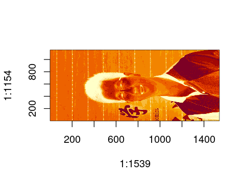

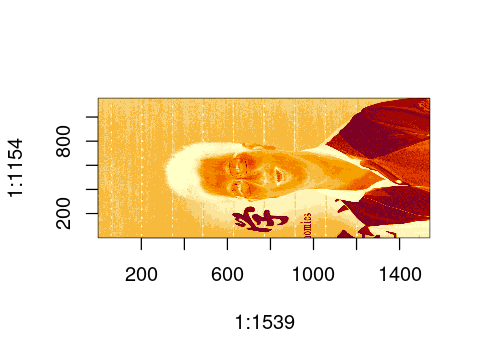

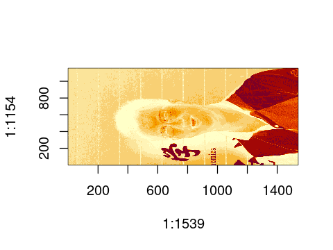

```r
# install.packages("jpeg")
library("jpeg")
   dim(myprofile)
image(1:1539, 1:1154, myprofile[, , 1])
image(1:1539, 1:1154, myprofile[, , 2])
image(1:1539, 1:1154, myprofile[, , 3])
```

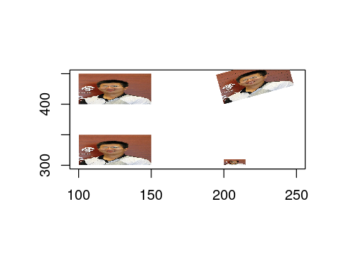

```r
plot(c(100, 250), c(300, 450), type = "n", xlab = "", ylab = "")
rasterImage(myprofile, 100, 300, 150, 350, interpolate = FALSE)
rasterImage(myprofile, 100, 400, 150, 450)
rasterImage(myprofile, 200, 300, 200 + xinch(.5),
            300 + yinch(.3), interpolate = FALSE)
rasterImage(myprofile, 200, 400, 250, 450,
            angle = 15, interpolate = FALSE)
```

## R and Database

- SQL has limited numerical and statistical features. For example, it has no least squares fitting procedures, and to find quantiles requires a sophisticated query.
- Not only are basic statistical functions missing from SQL, but in many cases the numerical algorithms used in the basic aggregate functions are not implemented to safeguard numerical accuracy.
- For these reasons, it may be desirable or even necessary to perform a statistical analysis in a statistical package rather than in the database. One way to do this, is to extract the data from the database and import it into statistical software.
- The `RODBC` package provides access to databases (including Microsoft Access and Microsoft SQL Server) through an ODBC interface.

  ```
    odbcConnect(dsn, uid="", pwd="")
    sqlFetch(channel, sqtable)
    sqlQuery(channel, query)
    sqlSave(channel, mydf, tablename = sqtable, append = FALSE)
    sqlDrop(channel, sqtable)
  ```

- Use the `RODBC` package to read Oracle Database.
- The `DBI` package in R provides a uniform, client- side interface to different database management systems, such as MySQL, PostgreSQL, and Oracle.
- The `RMySQL` package provides an interface to MySQL.
- The `ROracle` package provides an interface for Oracle.
- The `RJDBC` package provides access to databases through a JDBC interface.

### Further Suggested Read

- R Data Import/Export

  http://cran.r-project.org/doc/manuals/r-release/R-data.pdf